# AML - Phase 2: Feature Engineering

Autor:in

Luca Manna

Veröffentlichungsdatum

5. Juni 2026

In dieser Phase wird der **Client Analytical Record** erstellt. Eine Zeile pro Konto mit allen prädiktiven Features. Grundlage ist die `study_table` aus Phase 1, die für jedes Konto das Rollup-Zeitfenster `[rollup_start, rollup_end]`, das Target-Label und den Train/Test-Split definiert.

**Feature-Kategorien:** 1. **tsfresh (automatisch):** ~1’554 Features aus Transaktions-Zeitreihen (Betrag & Saldo) via `EfficientFCParameters`, reduziert auf 1’066 durch Korrelations-Deduplizierung 2. **Baseline (5 Features):** Alter, Geschlecht, Region, Vermögen, Umsatz — gemäss Aufgabenstellung 3. **Statische Features (20):** Bezirk, Kredit, Daueraufträge, Kontofrequenz 4. **Behavioral Features (30):** Transaktionstyp-Ratios, Operationsmuster, Verwendungszweck, Aktivitätsmetriken 5. **Window Features (12):** Temporale Sub-Fenster-Vergleiche (Quartal-/Halbjahrestrends, monatliche Steigung)

```python
import os
import sys
import time

import matplotlib.pyplot as plt
import numpy as np
import pandas as pd
import seaborn as sns
from tsfresh import select_features

# Add project root to path so we can import src
sys.path.insert(0, "..")

from src.data import (
    PATH_PROCESSED,
    RANDOM_STATE,
    load_raw_data,
    load_study_table,
    set_plot_style,
)
from src.features import (
    BASELINE_FEATURE_COLS,
    BEHAVIORAL_FEATURE_COLS,
    TSFRESH_FEATURE_PREFIX,
    WINDOW_FEATURE_COLS,
    build_feature_matrix,
    compute_baseline_features,
    compute_behavioral_features,
    compute_static_features,
    compute_tsfresh_features,
    compute_window_comparison_features,
    filter_transactions_to_rollup,
    get_feature_overview_table,
)

set_plot_style()
print("Imports OK")
```

```
Imports OK
```

```python
# Load raw data and study table
data = load_raw_data()
account, card, client, disp, district = (
    data["account"],
    data["card"],
    data["client"],
    data["disp"],
    data["district"],
)
loan, order, trans = data["loan"], data["order"], data["trans"]

study_table = load_study_table()

print(f"Study Table: {study_table.shape[0]} Accounts, {study_table.shape[1]} Spalten")
print(f"Transaktionen: {len(trans):,}")
print(f"\nTarget-Verteilung:")
print(study_table["target"].value_counts().sort_index().to_string())
```

```
Study Table: 3893 Accounts, 8 Spalten
Transaktionen: 1,056,320

Target-Verteilung:
target
0    3353
1     540
```

## 1 Data Pipeline Übersicht

Die Feature-Engineering-Pipeline transformiert die Rohdaten in einen flachen Feature-Vektor pro Konto:

```
Raw Tables (8 CSVs)
    │
    ├── trans (1M+ rows) ──► Rollup Filter [rollup_start, rollup_end] ──► trans_rollup (~280K rows)
    │                              │
    │                              ├── tsfresh EfficientFCParameters ──► ~1'554 auto Features (amount + balance)
    │                              │       └── Correlation Dedup ──► 1'066 unique tsfresh Features
    │                              ├── Baseline Aggregation ──► balance_last, turnover
    │                              ├── Behavioral Features ──► 30 Features (type, operation, k_symbol, bank, ratios)
    │                              └── Window Comparison ──► 12 Features (Q1-Q4, H1-H2 trends, monthly slope)
    │
    ├── client + disp ──► age_at_event, gender
    ├── district ──► avg_salary, unemployment, urban_ratio, inhabitants, entrepreneurs, crimes
    ├── loan (temporal guard) ──► has_loan, loan_amount, loan_monthly_payment
    ├── order ──► order_count, order_total_amount, has_insurance/household/loan_order
    └── account ──► frequency one-hot, months_to_event
                              │
                              ▼
                    Feature Matrix (1 row per account, ~1'130 features)
```

**Neue Feature-Gruppen (Phase 3.1):** - **Behavioral (30):** Transaktionstyp-Ratios (`type`), Operationsmuster (`operation`), Verwendungszweck (`k_symbol`), Aktivitätsmetriken, abgeleitete Verhältnisse - **Window (12):** Quartal- und Halbjahresvergleiche innerhalb des 12-Monats-Fensters (Balance-Trend Q1→Q4, Umsatz-Trend H1→H2, monatliche Balance-Steigung) - **tsfresh Dedup:** Greedy-Selektion nach Target-Korrelation mit Pearson-Schwelle 0.95 reduziert 1’554 auf 1’066 Features

**Leakage Guards:** - Transaktionen strikt auf `[rollup_start, rollup_end]` gefiltert (kein Lag-Zeitraum, keine Post-Event-Daten) - Kredite nur einbezogen wenn `loan.date <= rollup_end` - Feature Scaling/Encoding erst im sklearn Pipeline beim Modeling

```python
# === Transaktionen auf Rollup-Fenster filtern ===
trans_rollup = filter_transactions_to_rollup(trans, study_table)

print(f"Transaktionen vorher:  {len(trans):>10,}")
print(f"Transaktionen nachher: {len(trans_rollup):>10,}")
print(f"Reduktion:             {(1 - len(trans_rollup)/len(trans))*100:.1f}%")

# Stichproben-Check: Konten #14 und #18
print("\n--- Stichproben-Check ---")
for acc_id in [14, 18]:
    if acc_id in study_table["account_id"].values:
        row = study_table[study_table["account_id"] == acc_id].iloc[0]
        n_tx = (trans_rollup["account_id"] == acc_id).sum()
        print(
            f"Konto #{acc_id}: {n_tx} Transaktionen in [{row['rollup_start'].date()} .. {row['rollup_end'].date()}]"
        )
    else:
        print(f"Konto #{acc_id}: nicht in study_table (excluded)")
```

```
Transaktionen vorher:   1,056,320
Transaktionen nachher:    279,226
Reduktion:             73.6%

--- Stichproben-Check ---
Konto #14: 56 Transaktionen in [1997-02-01 .. 1998-02-01]
Konto #18: 67 Transaktionen in [1993-12-01 .. 1994-12-01]
```

## 2 tsfresh Feature Extraction

Wir verwenden `tsfresh` mit `EfficientFCParameters` um automatisch Features aus den Transaktions-Zeitreihen zu extrahieren. Für jedes Konto werden die `amount`- und `balance`-Zeitreihen innerhalb des Rollup-Fensters analysiert.

`EfficientFCParameters` umfasst 73 Feature-Funktionen (z.B. Autokorrelation, Entropy, FFT-Koeffizienten, lineare Trends, Quantile). Viele dieser Funktionen sind parametrisiert — z.B. berechnet die FFT-Funktion Koeffizienten für 100 Frequenzen, Quantile werden für mehrere q-Werte berechnet. Dadurch entstehen **~777 konkrete Features pro Zeitreihe**, also insgesamt **~1’554 Features** für die beiden Zeitreihen `amount` und `balance`.

**Konfiguration:** - `column_id`: account_id (gruppiert Zeitreihen pro Konto) - `column_sort`: zeitlicher Index (monoton steigend pro Konto) - `default_fc_parameters`: EfficientFCParameters (schneller als ComprehensiveFCParameters, aber noch umfangreich) - NaN/Inf werden nach der Extraktion via `tsfresh.utilities.dataframe_functions.impute()` bereinigt

```python
# === tsfresh Feature Extraction ===
t0 = time.time()
tsfresh_features = compute_tsfresh_features(trans_rollup, study_table)
elapsed = time.time() - t0

print(f"tsfresh Features: {tsfresh_features.shape}")
print(f"  Accounts: {tsfresh_features.shape[0]}")
print(f"  Features: {tsfresh_features.shape[1]}")
print(f"  Laufzeit: {elapsed:.1f} Sekunden ({elapsed/60:.1f} Minuten)")
print(f"\nBeispiel-Features (erste 10 Spalten):")
print(tsfresh_features.iloc[:3, :10].to_string())
```

```
tsfresh Features: (3891, 1554)
  Accounts: 3891
  Features: 1554
  Laufzeit: 165.8 Sekunden (2.8 Minuten)

Beispiel-Features (erste 10 Spalten):
            tsf_amount__variance_larger_than_standard_deviation  tsf_amount__has_duplicate_max  tsf_amount__has_duplicate_min  tsf_amount__has_duplicate  tsf_amount__sum_values  tsf_amount__abs_energy  tsf_amount__mean_abs_change  tsf_amount__mean_change  tsf_amount__mean_second_derivative_central  …
account_id
1                                                           1.0                            1.0                            1.0                        1.0                103555.1            2.845031e+08                  1345.890411               -32.509589                                   -8.075000  …
2                                                           1.0                            1.0                            1.0                        1.0                553730.7            8.497454e+09                  8342.387805               -87.075610                                   24.719136  …
3                                                           1.0                            1.0                            1.0                        1.0                200959.6            1.225523e+09                  3261.265753               -12.238356                                  -44.513889  …
```

### 2.1 tsfresh Feature-Analyse

```
Features mit NaN nach Imputation: 0
Features mit Null-Varianz (konstant): 323
Features mit Varianz > 0: 1231
```

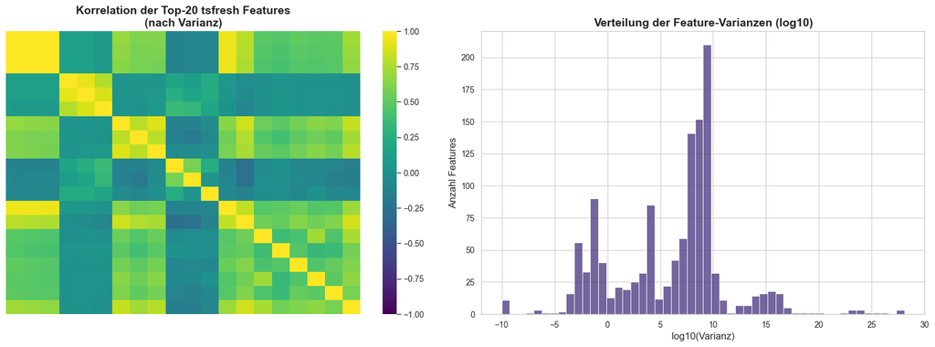

```python
# NaN-Anteil nach Imputation (sollte 0 sein)
nan_counts = tsfresh_features.isna().sum()
nan_nonzero = nan_counts[nan_counts > 0]
print(f"Features mit NaN nach Imputation: {len(nan_nonzero)}")

# Varianz-Analyse: Features mit Null-Varianz identifizieren
variances = tsfresh_features.var()
zero_var = (variances == 0).sum()
print(f"Features mit Null-Varianz (konstant): {zero_var}")
print(f"Features mit Varianz > 0: {(variances > 0).sum()}")

# Top-20 Features nach Varianz (normalisiert)
fig, axes = plt.subplots(1, 2, figsize=(16, 6))

# Korrelationsheatmap der Top-20 Features (nach Varianz)
top_var_cols = variances.nlargest(20).index.tolist()
corr_matrix = tsfresh_features[top_var_cols].corr()
sns.heatmap(
    corr_matrix,
    ax=axes[0],
    cmap="viridis",
    center=0,
    vmin=-1,
    vmax=1,
    xticklabels=False,
    yticklabels=False,
)
axes[0].set_title("Korrelation der Top-20 tsfresh Features\n(nach Varianz)")

# Verteilung der Feature-Varianzen (log-Skala)
sns.histplot(np.log10(variances[variances > 0] + 1e-10), bins=50, ax=axes[1])
axes[1].set_title("Verteilung der Feature-Varianzen (log10)")
axes[1].set_xlabel("log10(Varianz)")
axes[1].set_ylabel("Anzahl Features")

plt.tight_layout()
plt.show()
```

## 3 Baseline Features

Die 5 Baseline-Features sind gemäss Aufgabenstellung vorgeschrieben und bilden die Grundlage für das Baseline-Modell (Logistische Regression):

| Feature | Beschreibung | Quelle |
| --- | --- | --- |
| `age_at_event` | Alter des Kontoinhabers zum Ereigniszeitpunkt | client.birth_date, study_table.event_date |
| `gender` | Geschlecht (1=M, 0=F) | client.birth_number |
| `district_avg_salary` | Durchschnittsgehalt im Bezirk (= Region-Proxy) | district.A11 |
| `balance_last` | Letzter Kontostand im Rollup-Fenster (= Vermögen) | trans.balance |
| `turnover` | Summe der absoluten Beträge im Rollup (= Umsatz) | trans.amount |

```python
# === Baseline Features berechnen ===
baseline_features = compute_baseline_features(
    trans_rollup, study_table, client, disp, account, district
)

print("Baseline Features:")
print(baseline_features[BASELINE_FEATURE_COLS].describe().round(2).to_string())

# Spot-Check: Konten #14 und #18
print("\n--- Spot-Check: Konten #14 und #18 ---")
for acc_id in [14, 18]:
    if acc_id in baseline_features["account_id"].values:
        row = baseline_features[baseline_features["account_id"] == acc_id].iloc[0]
        print(f"\nKonto #{acc_id}:")
        print(f"  Vermögen (balance_last): {row['balance_last']:,.0f} CZK")
        print(f"  Umsatz (turnover):       {row['turnover']:,.0f} CZK")
        print(f"  Alter:                   {row['age_at_event']:.1f} Jahre")
        print(f"  Geschlecht:              {'M' if row['gender'] == 1 else 'F'}")
        print(f"  Bezirksgehalt:           {row['district_avg_salary']:,.0f} CZK")
    else:
        print(f"Konto #{acc_id}: nicht in study_table")
```

```
Baseline Features:
       age_at_event   gender  district_avg_salary  balance_last    turnover
count       3893.00  3893.00              3893.00       3891.00     3891.00
mean          45.49     0.51              9510.67      34024.45   405363.04
std           16.20     0.50              1321.27      19152.63   339950.32
min           17.32     0.00              8110.00     -10604.70     2600.00
25%           31.73     0.00              8547.00      19568.90   138419.80
50%           44.57     1.00              8991.00      29385.40   322286.10
75%           57.21     1.00              9897.00      44675.30   552894.75
max           80.80     1.00             12541.00     139329.90  2213467.40

--- Spot-Check: Konten #14 und #18 ---

Konto #14:
  Vermögen (balance_last): 35,600 CZK
  Umsatz (turnover):       382,781 CZK
  Alter:                   55.2 Jahre
  Geschlecht:              M
  Bezirksgehalt:           9,538 CZK

Konto #18:
  Vermögen (balance_last): 39,294 CZK
  Umsatz (turnover):       1,140,102 CZK
  Alter:                   55.5 Jahre
  Geschlecht:              F
  Bezirksgehalt:           9,425 CZK
```

### 3.1 Interpretation: Baseline Features

Die deskriptiven Statistiken zeigen plausible Wertebereiche:

- **age_at_event:** Durchschnitt 45.5 Jahre (Std 16.2), Spanne 17–81. Die breite Altersverteilung bietet gutes Diskriminierungspotenzial.
- **gender:** Nahezu ausgeglichen (51% männlich). Kein Geschlechter-Bias in der Stichprobe.
- **district_avg_salary:** Durchschnitt 9’511 CZK (Std 1’321). Relativ geringe Streuung. Die meisten Bezirke liegen im Bereich 8’100–12’500.
- **balance_last:** Durchschnitt 34’025 CZK mit hoher Streuung (Std 19’153). Minimum negativ (-10’605 CZK), was auf überziehbare Konten hindeutet. Rechtsschief verteilt.
- **turnover:** Durchschnitt 405’363 CZK, stark rechtsschief (Std 339’950). Einzelne Konten haben einen Umsatz von über 2 Mio. CZK.

**Spot-Check:** Konto #14 (Vermögen 35’600, Umsatz 383K) und Konto #18 (Vermögen 39’294, Umsatz 1.14M) zeigen deutlich unterschiedliche Umsatzniveaus bei ähnlichem Vermögen. Konto #18 hat einen ~3× höheren Umsatz, was auf intensivere Kontonutzung hindeutet. Beide Werte sind konsistent mit den Zeitreihenplots aus Phase 1. Zu beachten: 2 Konten haben keine Transaktionen im Rollup-Fenster (NaN für `balance_last` und `turnover`).

## 4 Statische Features

Zusätzlich zu den transaktionsbasierten Features fügen wir kontextuelle Informationen hinzu, die aus den statischen Tabellen (Bezirk, Kredit, Daueraufträge, Kontofrequenz) stammen. Diese Features verändern sich nicht innerhalb des Rollup-Fensters.

**Temporale Einschränkung:** Kredite werden nur einbezogen, wenn `loan.date <= rollup_end`, um Data Leakage zu vermeiden.

```python
# === Statische Features berechnen ===
static_features = compute_static_features(
    study_table, client, disp, account, district, loan, order
)

print(f"Statische Features: {static_features.shape[1] - 1} Spalten (ohne account_id)")
print(f"\nSpalten: {[c for c in static_features.columns if c != 'account_id']}")

# Stichprobe
print("\n--- Stichprobe (5 zufällige Konten) ---")
sample = static_features.sample(5, random_state=RANDOM_STATE)
print(sample.to_string(index=False))
```

```
Statische Features: 20 Spalten (ohne account_id)

Spalten: ['age_at_event', 'gender', 'district_avg_salary', 'district_unemployment_96', 'district_urban_ratio', 'district_inhabitants', 'district_entrepreneurs', 'district_crimes_96', 'loan_amount', 'loan_monthly_payment', 'has_loan', 'order_count', 'order_total_amount', 'has_insurance_order', 'has_h…

--- Stichprobe (5 zufällige Konten) ---
 account_id  age_at_event  gender  district_avg_salary  district_unemployment_96  district_urban_ratio  district_inhabitants  district_entrepreneurs  district_crimes_96  loan_amount  loan_monthly_payment  has_loan  order_count  order_total_amount  has_insurance_order  has_household_order  has_loan_o…
       2860     53.604381       0                 9897                      1.96                 100.0                387570                     140               18696          0.0                   0.0         0            0                 0.0                    0                    0            …
       2498     20.443532       1                 9317                      7.07                  85.3                128118                      97                6872          0.0                   0.0         0            2              6021.0                    0                    1            …
       1245     25.880903       1                 9893                      4.72                  57.2                228848                      96                5887          0.0                   0.0         0            1              3611.0                    0                    1            …
       3977     67.455168       1                 9920                      2.87                  63.4                 94725                     130                4846          0.0                   0.0         0            1              2974.0                    0                    1            …
       3861     48.254620       0                 8507                      1.85                  46.7                 88884                     132                2674          0.0                   0.0         0            1              4227.0                    0                    1            …
```

## 5 Behavioral Features (30)

Neue Features, die bisher ignorierte Transaktionsspalten nutzen: `type` (credit/withdrawal), `operation` (5 Operationsarten), `k_symbol` (Verwendungszweck), `bank` (externe Bankbeziehungen), sowie Aktivitäts- und Verhältnismetriken.

| Gruppe | Features | Beschreibung |
| --- | --- | --- |
| A — Volumen & Aktivität | 6 | Transaktionsanzahl, aktive Tage, Betrags-Statistiken, Saldo-Spannweite |
| B — Typ-Ratios | 4 | Anteil Credit/Withdrawal, Verhältnis, Durchschnittsbetrag Credit |
| C — Operationsmuster | 5 | Anteile der 5 Operationsarten (Bareinzahlung, Überweisung, etc.) |
| D — Verwendungszweck | 5 | Anteile nach k_symbol (Rente, Versicherung, Haushalt, Kredit) + Diversität |
| E — Temporale Muster | 6 | Tage zwischen Transaktionen, Wochenposition, externe Bankbeziehungen |
| F — Abgeleitete Ratios | 4 | Umsatz pro Transaktion, Saldo/Umsatz-Verhältnis, Netto-Fluss |

```python
# === Behavioral Features berechnen ===
behavioral_features = compute_behavioral_features(trans_rollup, study_table)

print(
    f"Behavioral Features: {behavioral_features.shape[1] - 1} Spalten (ohne account_id)"
)
print(f"\nSpalten: {BEHAVIORAL_FEATURE_COLS}")

# Descriptive stats
print("\n--- Deskriptive Statistik ---")
print(behavioral_features[BEHAVIORAL_FEATURE_COLS].describe().round(3).to_string())
```

```
Behavioral Features: 30 Spalten (ohne account_id)

Spalten: ['n_transactions', 'n_active_days', 'avg_amount', 'std_amount', 'median_amount', 'balance_range', 'pct_type_credit', 'pct_type_withdrawal', 'credit_withdrawal_ratio', 'avg_credit_amount', 'pct_op_collection_from_another_bank', 'pct_op_credit_in_cash', 'pct_op_withdrawal_in_cash', 'pct_op_re…

--- Deskriptive Statistik ---
       n_transactions  n_active_days  avg_amount  std_amount  median_amount  balance_range  pct_type_credit  pct_type_withdrawal  credit_withdrawal_ratio  avg_credit_amount  pct_op_collection_from_another_bank  pct_op_credit_in_cash  pct_op_withdrawal_in_cash  pct_op_remittance_to_another_bank  pct_…
count        3893.000       3893.000    3893.000    3893.000       3893.000       3893.000         3893.000             3893.000                 3893.000           3893.000                             3893.000               3893.000                   3893.000                           3893.000      …
mean           71.725         54.770    5393.924    6386.367       3015.394      43687.580            0.384                0.615                    0.644           7504.124                                0.085                  0.164                      0.529                              0.221      …
std            18.357         13.817    3929.697    4668.413       2483.270      33851.913            0.084                0.084                    0.316           5442.341                                0.113                  0.138                      0.117                              0.141      …
min             0.000          0.000       0.000       0.000          0.000          0.000            0.000                0.000                    0.000              0.000                                0.000                  0.000                      0.000                              0.000      …
25%            61.000         47.000    2168.993    2292.841       1380.000      17991.800            0.333                0.573                    0.484           2900.915                                0.000                  0.000                      0.451                              0.163      …
50%            71.000         54.000    4331.627    5300.884       2260.000      34340.100            0.380                0.620                    0.600           6141.400                                0.000                  0.190                      0.520                              0.216      …
75%            82.000         62.000    7682.964    9381.422       3959.100      54192.800            0.427                0.667                    0.727          11095.738                                0.203                  0.258                      0.597                              0.324      …
max           139.000        103.000   22929.408   23028.515      21800.000     181196.600            0.917                0.833                    5.500          27116.542                                0.414                  0.917                      0.865                              0.615      …
```

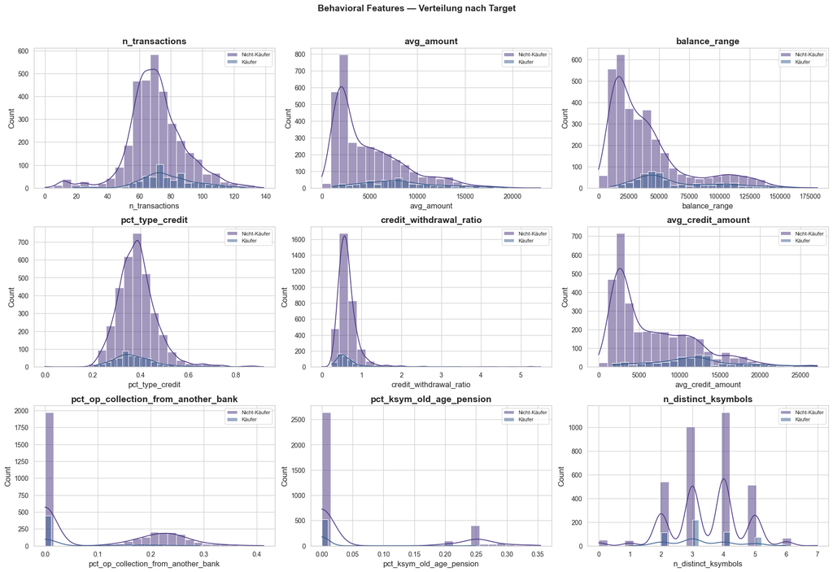

```python
# === Behavioral Features: Verteilungen nach Target ===
# Merge target for plotting
beh_with_target = behavioral_features.merge(
    study_table[["account_id", "target"]], on="account_id"
)

# Select most informative behavioral features for visualization
plot_beh_features = [
    "n_transactions",
    "avg_amount",
    "balance_range",
    "pct_type_credit",
    "credit_withdrawal_ratio",
    "avg_credit_amount",
    "pct_op_collection_from_another_bank",
    "pct_ksym_old_age_pension",
    "n_distinct_ksymbols",
]

fig, axes = plt.subplots(3, 3, figsize=(18, 12))
labels = {0: "Nicht-Käufer", 1: "Käufer"}
colors = {0: "C0", 1: "C1"}

for idx, feat in enumerate(plot_beh_features):
    ax = axes[idx // 3, idx % 3]
    for t in [0, 1]:
        subset = beh_with_target[beh_with_target["target"] == t]
        sns.histplot(
            subset[feat],
            bins=25,
            alpha=0.5,
            label=labels[t],
            ax=ax,
            kde=True,
            color=colors[t],
        )
    ax.set_title(feat)
    ax.legend(fontsize=8)

plt.suptitle(
    "Behavioral Features — Verteilung nach Target",
    fontsize=14,
    fontweight="bold",
    y=1.02,
)
plt.tight_layout()
plt.show()
```

## 6 Window Comparison Features (12)

Temporale Sub-Fenster innerhalb des 12-Monats-Rollup: Vergleicht Kontoverhalten zwischen Quartalen (Q1=älteste 3 Monate, Q4=neueste 3 Monate) und Halbjahren (H1/H2). Erlaubt die Erfassung von **Trends** wie “Saldo wächst” oder “Umsatz beschleunigt sich”.

```python
# === Window Comparison Features berechnen ===
window_features = compute_window_comparison_features(trans_rollup, study_table)

print(f"Window Features: {window_features.shape[1] - 1} Spalten (ohne account_id)")
print(f"\nSpalten: {WINDOW_FEATURE_COLS}")

# Descriptive stats
print("\n--- Deskriptive Statistik ---")
print(window_features[WINDOW_FEATURE_COLS].describe().round(2).to_string())
```

```
Window Features: 12 Spalten (ohne account_id)

Spalten: ['balance_mean_q1', 'balance_mean_q4', 'balance_trend_q1_q4', 'balance_trend_q1_q4_pct', 'turnover_h1', 'turnover_h2', 'turnover_trend_h1_h2', 'turnover_trend_h1_h2_pct', 'n_tx_h1', 'n_tx_h2', 'tx_count_trend_h1_h2', 'monthly_balance_slope']

--- Deskriptive Statistik ---
       balance_mean_q1  balance_mean_q4  balance_trend_q1_q4  balance_trend_q1_q4_pct  turnover_h1  turnover_h2  turnover_trend_h1_h2  turnover_trend_h1_h2_pct  n_tx_h1  n_tx_h2  tx_count_trend_h1_h2  monthly_balance_slope
count          3893.00          3893.00              3893.00                  3893.00      3893.00      3893.00               3893.00                   3893.00  3893.00  3893.00               3893.00                3893.00
mean          34615.39         35526.53               929.35                     0.13    199620.28    205534.51               5914.23                      0.28    34.14    37.59                  3.45                 105.11
std           16563.16         17895.33             13187.33                     1.20    177418.83    180176.49             110863.84                      6.91    10.66     9.72                  8.92                1407.80
min           -2952.37         -6042.97            -78986.28                    -1.74         0.00         0.00           -1030691.70                     -1.00     0.00     0.00                -31.00               -8387.61
25%           21985.56         21098.01             -5139.26                    -0.16     65934.00     69568.10             -10269.00                     -0.07    28.00    32.00                 -4.00                -565.58
50%           31185.56         31770.23               724.93                     0.03    154852.40    160712.20               1828.20                      0.02    34.00    37.00                  3.00                  97.47
75%           44797.33         47066.23              7165.32                     0.24    269446.10    274619.00              15247.40                      0.16    40.00    43.00                  9.00                 764.01
max           97928.96        103694.78             65412.91                    52.74   1227969.60   1138623.20             851212.10                    423.76    78.00    74.00                 44.00                7558.80
```

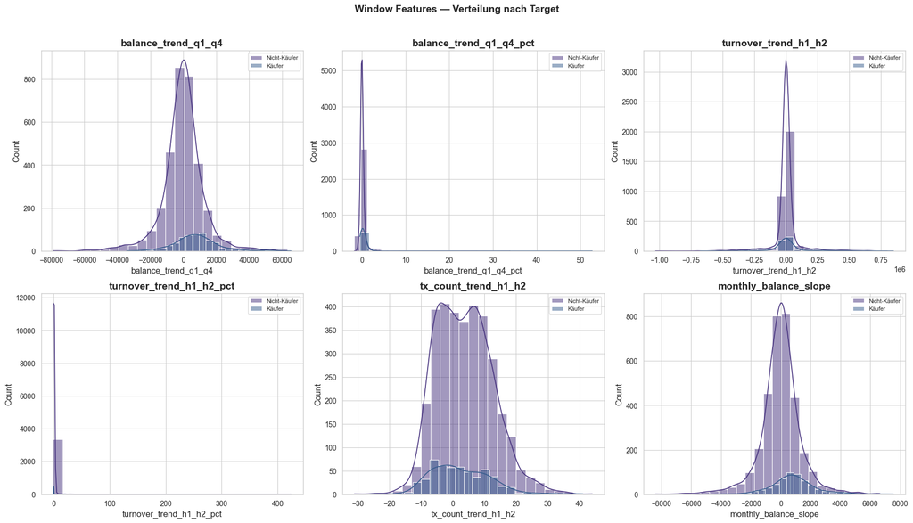

```python
# === Window Features: Verteilungen nach Target ===
win_with_target = window_features.merge(
    study_table[["account_id", "target"]], on="account_id"
)

plot_win_features = [
    "balance_trend_q1_q4",
    "balance_trend_q1_q4_pct",
    "turnover_trend_h1_h2",
    "turnover_trend_h1_h2_pct",
    "tx_count_trend_h1_h2",
    "monthly_balance_slope",
]

fig, axes = plt.subplots(2, 3, figsize=(18, 10))
for idx, feat in enumerate(plot_win_features):
    ax = axes[idx // 3, idx % 3]
    for t in [0, 1]:
        subset = win_with_target[win_with_target["target"] == t]
        sns.histplot(
            subset[feat],
            bins=25,
            alpha=0.5,
            label=labels[t],
            ax=ax,
            kde=True,
            color=colors[t],
        )
    ax.set_title(feat)
    ax.legend(fontsize=8)

plt.suptitle(
    "Window Features — Verteilung nach Target", fontsize=14, fontweight="bold", y=1.02
)
plt.tight_layout()
plt.show()
```

### 6.1 Interpretation: Window Comparison Features

#### 6.1.2 Verteilungen nach Target

Die Histogramme zeigen für alle sechs dargestellten Trend-Features eine **starke Überlappung der Buyer- und Non-Buyer-Verteilungen**. Keines der Trend-Features allein trennt die Klassen klar. Das ist ein wichtiger Befund:

> **Nicht der Trend, sondern das absolute Niveau entscheidet.** Die Permutation-Importance-Analyse (Phase 3) bestätigt dies: `balance_mean_q4` (absoluter Saldo im letzten Quartal) ist das stärkste Feature, während Trend-Features wie `balance_trend_q1_q4` und `monthly_balance_slope` weiter hinten ranken.

Die Window Features leisten dennoch einen Beitrag: Für nicht-lineare Modelle (Tree-Ensembles) können sie in Kombination mit anderen Features Interaktionseffekte erfassen — z.B. “hohes Niveau UND steigender Trend” als besonders starkes Signal.

## 7 Übersicht aller handgefertigten Features

Das Modell kombiniert zwei Feature-Arten: **handgefertigte Features** mit expliziter domänen-spezifischer Rationale (Domain Knowledge aus Bank- und Marketing-Kontext) sowie **tsfresh-extrahierte Zeitreihenfeatures** als breite, automatische Ergänzung. Die folgende Master-Tabelle dokumentiert alle **64 unique handgefertigten Features** (5 Baseline + 17 Static-only + 30 Behavioral + 12 Window — `age_at_event`, `gender` und `district_avg_salary` erscheinen sowohl in `BASELINE_FEATURE_COLS` als auch `STATIC_FEATURE_COLS` und werden hier einmalig unter Baseline geführt) inklusive Datenquelle, Berechnungslogik und Prognose-Hypothese. Sie dient als zentrale Referenz für Reviewer und Domain Experts.

| Feature | Kategorie | Quelle | Berechnung | Rationale |
| --- | --- | --- | --- | --- |
| `age_at_event` | Baseline | client.birth_date, study_table.event_date | (event_date − birth_date) in Jahren | Lebensphase steuert Kreditkarten-Nachfrage (Erwerbstätige vs. Senioren) |
| `gender` | Baseline | client.birth_number | 1 wenn männlich, sonst 0 (aus YY(MM+50)DD-Kodierung) | Demografisches Standard-Stratum; geringe erwartete Eigenwirkung, aber Interaktionspotenzial |
| `district_avg_salary` | Baseline | district.A11 (via account.district_id) | direkter Wert aus Bezirkstabelle | Region-Proxy für Kaufkraft; höhere Gehälter ↔︎ höhere Affinität zu Premium-Produkten |
| `balance_last` | Baseline | trans.balance | letzter Saldo im [rollup_start, rollup_end]-Fenster | Vermögensindikator zum Ereigniszeitpunkt; höherer Saldo ↔︎ höhere Kapazität für Kreditkartenangebot |
| `turnover` | Baseline | trans.amount | sum(abs(amount)) im Rollup | Aktivitätsniveau des Kontos; aktive Kunden sind eher empfänglich für Cross-Selling |
| `district_unemployment_96` | District | district.A13 | Arbeitslosenquote 1996 im Bezirk | Wirtschaftliche Lage der Region beeinflusst Kreditrisiko und Konsumneigung |
| `district_urban_ratio` | District | district.A10 | Anteil städtischer Einwohner im Bezirk | Urbane Kunden zeigen typischerweise höhere Affinität zu bargeldlosen Zahlungsmitteln |
| `district_inhabitants` | District | district.A4 | Einwohnerzahl des Bezirks | Marktgrösse-Proxy; grössere Bezirke bieten breitere Vergleichsbasis |
| `district_entrepreneurs` | District | district.A14 | Anzahl Unternehmer im Bezirk | Indikator für wirtschaftliche Dynamik und mögliche Geschäftskunden |
| `district_crimes_96` | District | district.A16 | Anzahl Verbrechen 1996 im Bezirk | Sozioökonomischer Risikoindikator des Bezirks |
| `has_loan` | Loan | loan.account_id (mit loan.date ≤ rollup_end) | 1 wenn aktiver Kredit existiert, sonst 0 | Bestehende Kreditbeziehung signalisiert Bereitschaft, Kreditprodukte zu nutzen |
| `loan_amount` | Loan | loan.amount | Summe der Kreditbeträge (temporal-guarded) | Höhe der bestehenden Verschuldung als Vermögens-/Risiko-Indikator |
| `loan_monthly_payment` | Loan | loan.payments | Summe der monatlichen Raten (temporal-guarded) | Monatliche Belastung beeinflusst frei verfügbares Einkommen |
| `order_count` | Order | order.order_id | Anzahl Daueraufträge pro Konto | Aktive Nutzung automatisierter Zahlungen ↔︎ Affinität zu modernen Bankdienstleistungen |
| `order_total_amount` | Order | order.amount | sum(amount) aller Daueraufträge | Volumen wiederkehrender Verpflichtungen |
| `has_insurance_order` | Order | order.k_symbol = “insurance_payment” | 1 wenn Versicherungs-Dauerauftrag existiert, sonst 0 | Vorsorgeverhalten korreliert mit Finanz-Affinität |
| `has_household_order` | Order | order.k_symbol = “household_payment” | 1 wenn Haushalts-Dauerauftrag existiert, sonst 0 | Strukturierte Ausgabengestaltung als Reife-Indikator |
| `has_loan_order` | Order | order.k_symbol = “loan_payment” | 1 wenn Kredit-Dauerauftrag existiert, sonst 0 | Bedient bestehende Kredite → eher kreditkartenaffin |
| `freq_monthly` | Account | account.frequency | One-Hot: 1 wenn “POPLATEK MESICNE” | Standardprofil; Referenzgruppe für Frequenzvergleich |
| `freq_weekly` | Account | account.frequency | One-Hot: 1 wenn “POPLATEK TYDNE” | Wöchentliche Abrechnung = häufigere Interaktion mit Bank |
| `freq_after_transaction` | Account | account.frequency | One-Hot: 1 wenn “POPLATEK PO OBRATU” | Transaktionsabhängige Frequenz = besonders aktive Nutzer |
| `months_to_event` | Account | study_table | Monate von Kontoeröffnung bis Ereignisdatum | Kontoalter; reife Kundenbeziehungen erlauben fundiertere Affinitätsschätzung |
| `n_transactions` | Behavioral A | trans.account_id | Anzahl Transaktionen im Rollup | Aktivitäts-Volumen; aktive Kunden zeigen mehr Bindung |
| `n_active_days` | Behavioral A | trans.date | Anzahl distinkter Transaktionstage | Streuung der Aktivität über die Zeit, robuster als reine Anzahl |
| `avg_amount` | Behavioral A | trans.amount | mean(abs(amount)) im Rollup | Typische Transaktionsgrösse als Wohlstands-Proxy |
| `std_amount` | Behavioral A | trans.amount | std(abs(amount)) im Rollup | Volatilität der Transaktionsbeträge; stabile Muster ↔︎ planbare Finanzen |
| `median_amount` | Behavioral A | trans.amount | median(abs(amount)) im Rollup | Robuste Lagemetrik gegenüber Ausreissern |
| `balance_range` | Behavioral A | trans.balance | max(balance) − min(balance) im Rollup | Spannweite des Saldos; geringe Spanne ↔︎ stabile Liquidität |
| `pct_type_credit` | Behavioral B | trans.type | Anteil der Credit-Transaktionen | Hoher Einkommens-Anteil ↔︎ regelmässige Gehaltszahlungen |
| `pct_type_withdrawal` | Behavioral B | trans.type | Anteil der Withdrawal-Transaktionen | Komplement zu pct_type_credit; Konsumneigung |
| `credit_withdrawal_ratio` | Behavioral B | trans.type | n_credit / (n_withdrawal + 1) | Anteil regelmässiger Einzahlungen (z.B. Gehalt) vs. Auszahlungen — Käufer könnten stabilere Einkommenströme zeigen |
| `avg_credit_amount` | Behavioral B | trans.amount, trans.type | mean(abs(amount)) wo type = credit | Durchschnittliches Gehalts-/Einkommensniveau |
| `pct_op_collection_from_another_bank` | Behavioral C | trans.operation | Anteil eingehender Überweisungen externer Banken | Hinweis auf externe Geschäfts-/Mietbeziehungen |
| `pct_op_credit_in_cash` | Behavioral C | trans.operation | Anteil Bareinzahlungen | Klassisches Verhalten; geringer Anteil ↔︎ Affinität zu bargeldlosen Mitteln |
| `pct_op_withdrawal_in_cash` | Behavioral C | trans.operation | Anteil Barabhebungen | Hoher Anteil ↔︎ präferiertes Bargeldverhalten, eher konservativ |
| `pct_op_remittance_to_another_bank` | Behavioral C | trans.operation | Anteil ausgehender Überweisungen an externe Banken | Engagiertes Banking-Verhalten, mehrere Bankbeziehungen |
| `pct_op_credit_card_withdrawal` | Behavioral C | trans.operation | Anteil Kreditkarten-Abhebungen | Direkte Nutzungserfahrung mit Kartenprodukten (falls vorhanden) |
| `pct_ksym_old_age_pension` | Behavioral D | trans.k_symbol | Anteil Renteneingänge | Senioren-Indikator; Rentner haben oft geringere Kreditkarten-Affinität |
| `pct_ksym_insurance_payment` | Behavioral D | trans.k_symbol | Anteil Versicherungszahlungen | Vorsorgebewusstsein ↔︎ Affinität zu Finanzprodukten |
| `pct_ksym_household_payment` | Behavioral D | trans.k_symbol | Anteil Haushaltszahlungen | Etabliertes Haushaltsmanagement, Verbraucherreife |
| `pct_ksym_loan_payment` | Behavioral D | trans.k_symbol | Anteil Kreditzahlungen | Aktive Kreditbedienung ↔︎ kreditkartenkompatibles Profil |
| `n_distinct_ksymbols` | Behavioral D | trans.k_symbol | Anzahl distinkter (nicht-leerer) Verwendungszwecke | Diversität der Kontonutzung; vielfältige Nutzer sind cross-selling-affiner |
| `avg_days_between_tx` | Behavioral E | trans.date | mean der Tage zwischen aufeinanderfolgenden Transaktionen | Regelmässigkeit der Nutzung; geringer Abstand ↔︎ aktiver Kunde |
| `std_days_between_tx` | Behavioral E | trans.date | std der Tage zwischen Transaktionen | Volatilität der Nutzungsmuster; konstante Muster sind prädiktiv stabiler |
| `pct_tx_first_week` | Behavioral E | trans.date | Anteil Transaktionen mit Monatstag ≤ 7 | Monatsanfangs-Aktivität (Gehaltszahlungen, Mieten) |
| `pct_tx_last_week` | Behavioral E | trans.date | Anteil Transaktionen mit Monatstag ≥ 24 | Monatsende-Aktivität, oft Konsum/Wochenende |
| `n_distinct_banks` | Behavioral E | trans.bank | Anzahl distinkter externer Banken | Multi-Banking-Verhalten ↔︎ finanzielle Komplexität und Reife |
| `has_external_bank_tx` | Behavioral E | trans.bank | 1 wenn mind. eine externe Banktransaktion, sonst 0 | Bestehende externe Beziehungen erweitern den Marktkontext |
| `turnover_per_transaction` | Behavioral F | trans.amount | sum(abs(amount)) / n_transactions | Durchschnittliche Transaktionsgrösse, robust gegenüber Volumen |
| `balance_to_turnover_ratio` | Behavioral F | trans.balance, trans.amount | balance_last / (sum(abs(amount)) + 1) | Liquiditätsreserve im Verhältnis zum Umsatz; hoher Wert ↔︎ Sparsamkeit |
| `net_flow` | Behavioral F | trans.amount, trans.type | sum(credit-amounts) − sum(withdrawal-amounts) | Netto-Geldfluss im Rollup; positiver Fluss ↔︎ Vermögensaufbau |
| `net_flow_ratio` | Behavioral F | trans.amount, trans.type | net_flow / (turnover + 1) | Relativer Netto-Fluss, robust gegenüber Kontogrösse |
| `balance_mean_q1` | Window | trans.balance, trans.date | mean(balance) im Quartal 1 (älteste 3 Monate) | Saldoniveau im frühen Beobachtungsfenster |
| `balance_mean_q4` | Window | trans.balance, trans.date | mean(balance) im Quartal 4 (jüngste 3 Monate) | Saldoniveau zum Ereigniszeitpunkt |
| `balance_trend_q1_q4` | Window | trans.balance, trans.date | balance_mean_q4 − balance_mean_q1 | Absoluter Saldo-Trend über das Rollup-Fenster |
| `balance_trend_q1_q4_pct` | Window | trans.balance, trans.date | (q4 − q1) / (abs(q1) + 1) | Relativer Saldo-Trend; robust gegenüber Niveau |
| `turnover_h1` | Window | trans.amount, trans.date | sum(abs(amount)) im Halbjahr 1 | Aktivitätsvolumen in der älteren Hälfte |
| `turnover_h2` | Window | trans.amount, trans.date | sum(abs(amount)) im Halbjahr 2 | Aktivitätsvolumen in der jüngeren Hälfte |
| `turnover_trend_h1_h2` | Window | trans.amount, trans.date | turnover_h2 − turnover_h1 | Wachsender Umsatz ↔︎ steigende Bankaktivität |
| `turnover_trend_h1_h2_pct` | Window | trans.amount, trans.date | (h2 − h1) / (h1 + 1) | Relativer Umsatz-Trend, robust gegenüber Volumen |
| `n_tx_h1` | Window | trans.account_id, trans.date | Anzahl Transaktionen im Halbjahr 1 | Aktivitätshäufigkeit im älteren Halbjahr |
| `n_tx_h2` | Window | trans.account_id, trans.date | Anzahl Transaktionen im Halbjahr 2 | Aktivitätshäufigkeit im jüngeren Halbjahr |
| `tx_count_trend_h1_h2` | Window | trans.account_id, trans.date | n_tx_h2 − n_tx_h1 | Steigende Frequenz ↔︎ wachsende Bindung an die Bank |
| `monthly_balance_slope` | Window | trans.balance, trans.date | OLS-Steigung der monatlichen Saldo-Mittelwerte über 12 Monate | Aufwärtstrend des Saldos = wachsende Liquidität = potenziell höhere Affinität zu Premiumprodukten |

### 7.1 tsfresh-Gruppenübersicht

Zusätzlich zu den 64 handgefertigten Features extrahiert `tsfresh` aus den Zeitreihen `amount` und `balance` ein breites Spektrum statistischer Deskriptoren. Diese werden nicht einzeln gepflegt, sondern via Korrelations-Deduplizierung gefiltert. Die folgende Tabelle gruppiert die ~1’554 tsfresh-Features nach funktionalem Typ:

| tsfresh-Gruppe | Beispielfunktionen | Was wird gemessen |
| --- | --- | --- |
| Lageparameter | `mean`, `median`, `quantile_q` | Saldoniveau über den Rollup |
| Streuung | `std`, `variance`, `mean_abs_change` | Volatilität der Zeitreihe |
| Autokorrelation | `autocorrelation`, `c3`, `partial_autocorrelation` | Persistenz und Nichtlinearität |
| Spektral | `fft_coefficient`, `welch_density` | Periodizität (z.B. monatliche Zyklen) |
| Entropie/Komplexität | `approximate_entropy`, `sample_entropy`, `cid_ce` | Vorhersagbarkeit der Zeitreihe |
| Trend | `linear_trend`, `agg_linear_trend` | Drift im Saldo/Umsatz |
| Sonstige | `benford_correlation`, `abs_energy`, `count_above_mean` | diverse Detektoren |

tsfresh extrahiert mit `EfficientFCParameters` ~777 Features pro Zeitreihe (`amount` + `balance` = ~1’554 total), reduziert via Korrelations-Deduplizierung (Schwelle 0.95) auf 1’066 nicht-redundante Spalten. Diese ergänzen die 64 handgefertigten Features mit klarer Domänen-Interpretation um eine breite statistische Abdeckung der Zeitreihen-Dynamik.

Die exakten Definitionen aller Features finden sich in `src/features.py` (Funktionen `compute_baseline_features`, `compute_static_features`, `compute_behavioral_features`, `compute_window_comparison_features`).

## 8 Feature Matrix zusammenführen

Alle Feature-Gruppen (tsfresh, Baseline, Statisch) werden zu einer einzigen Feature-Matrix zusammengeführt. Die Matrix hat genau eine Zeile pro Konto und enthält `target` und `split` als Metadaten-Spalten.

```python
# === Feature Matrix zusammenführen ===
feature_matrix = build_feature_matrix(
    study_table=study_table,
    trans=trans,
    client=client,
    disp=disp,
    account=account,
    district=district,
    loan=loan,
    order=order,
    include_tsfresh=True,
)

feature_cols = [
    c for c in feature_matrix.columns if c not in ("account_id", "target", "split")
]
print(f"\nFeature Matrix Shape: {feature_matrix.shape}")
print(f"  Accounts: {feature_matrix.shape[0]}")
print(f"  Features: {len(feature_cols)}")
print(f"  Metadata: account_id, target, split")
print(f"\nDtype-Übersicht:")
print(feature_matrix[feature_cols].dtypes.value_counts().to_string())
```

```
Filtering transactions to rollup windows...
  1056320 -> 279226 transactions in rollup windows
Computing tsfresh features (this may take a few minutes)...
```

```
  1554 tsfresh features extracted
Computing baseline features...
Computing static features...
Computing behavioral features (30 features)...
  30 behavioral features computed
Computing window comparison features (12 features)...
  12 window features computed
Deduplicating tsfresh features (corr_threshold=0.95)...
  1554 -> 1066 tsfresh features after deduplication
Assembling feature matrix...
Feature matrix: 3893 accounts x 1130 features

Feature Matrix Shape: (3893, 1133)
  Accounts: 3893
  Features: 1130
  Metadata: account_id, target, split

Dtype-Übersicht:
float64    1114
int64        16
```

```python
# === Deliverable: Übersicht der selber konstruierten Predictive Features ===
overview = get_feature_overview_table(feature_matrix)

# Zusammenfassung nach Kategorie
print("Feature-Übersicht nach Kategorie:")
print(overview.groupby("category").size().sort_values(ascending=False).to_string())

# Nicht-tsfresh Features im Detail
non_tsf = overview[overview["category"] != "tsfresh (auto)"]
print(f"\n--- Handgefertigte Features ({len(non_tsf)}) ---")
print(
    non_tsf[
        ["feature_name", "category", "dtype", "mean", "std", "min", "max"]
    ].to_string(index=False)
)
```

```
Feature-Übersicht nach Kategorie:
category
tsfresh (auto)    1066
behavioral          30
window              12
baseline             5
district             5
account              4
loan                 4
order                4

--- Handgefertigte Features (64) ---
                       feature_name   category   dtype      mean       std         min        max
                       balance_last   baseline float64  34024.45  19152.63   -10604.70  139329.90
                           turnover   baseline float64 405363.04 339950.32     2600.00 2213467.40
                       age_at_event   baseline float64     45.49     16.20       17.32      80.80
                             gender   baseline   int64      0.51      0.50        0.00       1.00
                district_avg_salary   baseline   int64   9510.67   1321.27     8110.00   12541.00
           district_unemployment_96   district float64      3.50      2.13        0.43       9.40
               district_urban_ratio   district float64     69.07     19.78       33.90     100.00
               district_inhabitants   district   int64 268008.69 356620.93    42821.00 1204953.00
             district_entrepreneurs   district   int64    120.92     23.17       81.00     167.00
                 district_crimes_96   district   int64  16182.82  31134.83      888.00   99107.00
                        loan_amount       loan float64  18895.17  63601.31        0.00  590820.00
               loan_monthly_payment       loan float64    526.32   1590.32        0.00    9910.00
                           has_loan       loan   int64      0.13      0.33        0.00       1.00
                        order_count      order   int64      1.46      1.09        0.00       5.00
                 order_total_amount      order float64   4731.47   3924.02        0.00   22704.30
                has_insurance_order      order   int64      0.12      0.32        0.00       1.00
                has_household_order      order   int64      0.77      0.42        0.00       1.00
                     has_loan_order       loan   int64      0.16      0.37        0.00       1.00
             freq_after_transaction    account   int64      0.02      0.14        0.00       1.00
                       freq_monthly    account   int64      0.93      0.26        0.00       1.00
                        freq_weekly    account   int64      0.05      0.22        0.00       1.00
                    months_to_event    account   int64     24.77     10.86       13.00      71.00
                     n_transactions behavioral float64     71.73     18.36        0.00     139.00
                      n_active_days behavioral float64     54.77     13.82        0.00     103.00
                         avg_amount behavioral float64   5393.92   3929.70        0.00   22929.41
                         std_amount behavioral float64   6386.37   4668.41        0.00   23028.52
                      median_amount behavioral float64   3015.39   2483.27        0.00   21800.00
```

[output cut: 22 more lines]

```
          balance_to_turnover_ratio behavioral float64      0.14      0.18       -0.03       4.15
                           net_flow behavioral float64  17792.54  36536.63   -77993.00  243956.80
                     net_flow_ratio behavioral float64      0.04      0.09       -0.73       0.91
                    balance_mean_q1     window float64  34615.39  16563.16    -2952.37   97928.96
                    balance_mean_q4     window float64  35526.53  17895.33    -6042.97  103694.78
                balance_trend_q1_q4     window float64    929.35  13187.33   -78986.28   65412.91
            balance_trend_q1_q4_pct     window float64      0.13      1.20       -1.74      52.74
                        turnover_h1     window float64 199620.28 177418.83        0.00 1227969.60
                        turnover_h2     window float64 205534.51 180176.49        0.00 1138623.20
               turnover_trend_h1_h2     window float64   5914.23 110863.84 -1030691.70  851212.10
           turnover_trend_h1_h2_pct     window float64      0.28      6.91       -1.00     423.76
                            n_tx_h1     window float64     34.14     10.66        0.00      78.00
                            n_tx_h2     window float64     37.59      9.72        0.00      74.00
               tx_count_trend_h1_h2     window float64      3.45      8.92      -31.00      44.00
              monthly_balance_slope     window float64    105.11   1407.80    -8387.61    7558.80
```

```python
# === Deliverable: Buyer vs Non-Buyer mit vollständigem Rollup ===

ct = pd.crosstab(
    feature_matrix["target"].map({0: "Nicht-Käufer (0)", 1: "Käufer (1)"}),
    feature_matrix["split"],
    margins=True,
)
print("=== Käufer vs. Nicht-Käufer mit vollständigem Rollup ===")
print(ct.to_string())

print(f"\nTotal Accounts mit Feature Matrix: {len(feature_matrix)}")
print(f"  davon Käufer (Target=1):     {(feature_matrix['target'] == 1).sum()}")
print(f"  davon Nicht-Käufer (Target=0): {(feature_matrix['target'] == 0).sum()}")
```

```
=== Käufer vs. Nicht-Käufer mit vollständigem Rollup ===
split             test  train   All
target
Käufer (1)         109    431   540
Nicht-Käufer (0)   673   2680  3353
All                782   3111  3893

Total Accounts mit Feature Matrix: 3893
  davon Käufer (Target=1):     540
  davon Nicht-Käufer (Target=0): 3353
```

### 8.1 Interpretation: Feature-Matrix Assembly & Deliverables

#### 8.1.1 Feature Matrix (3’893 × 1’133)

Die finale Feature Matrix enthält **3’893 Accounts** mit **1’130 Prädiktoren** und 3 Metadaten-Spalten (`account_id`, `target`, `split`). Sie setzt sich zusammen aus:

| Kategorie | Anzahl | Anteil |
| --- | --- | --- |
| tsfresh (automatisch) | 1’066 | 94.3% |
| Behavioral (handgefertigt) | 30 | 2.7% |
| Window Comparison (handgefertigt) | 12 | 1.1% |
| Baseline | 5 | 0.4% |
| District | 5 | 0.4% |
| Account | 4 | 0.4% |
| Loan | 4 | 0.4% |
| Order | 4 | 0.4% |
| **Total handgefertigt** | **64** | **5.7%** |

Die tsfresh-Extraktion startete mit 1’554 Features, reduzierte durch Deduplizierung (Korrelation > 0.95) auf **1’066** — ein Drittel der Features war redundant. Von den ursprünglichen 1’056’320 Transaktionen verblieben nach Rollup-Filterung **279’226** (26.4%) für die Feature-Berechnung.

#### 8.1.2 Klassen-Ungleichgewicht & Split (Deliverable)

|  | Test | Train | Gesamt |
| --- | --- | --- | --- |
| Käufer (1) | 109 | 431 | **540** |
| Nicht-Käufer (0) | 673 | 2’680 | **3’353** |
| **Total** | **782** | **3’111** | **3’893** |

**Prävalenz: 13.9%** — auf je ~7 Konten kommt 1 Käufer. Der stratifizierte Split bewahrt diese Verteilung exakt in beiden Partitionen (Train: 431/3’111 = 13.9%, Test: 109/782 = 13.9%).

**Datenreduktion:** Von den ursprünglich 4’500 Konten haben 3’893 (86.5%) ein vollständiges 12-Monats-Rollup-Fenster. Die 607 ausgeschlossenen Konten hatten zu kurze Transaktionshistorien — ein erwartbarer Verlust bei einem historischen Datensatz.

**Klassen-Ungleichgewicht (Ratio 1:6.2)** ist moderat für einen Marketing-Datensatz. Die Verwendung von `class_weight="balanced"` in allen Modellen kompensiert dieses Ungleichgewicht durch implizite Upweighting der Minority-Class beim Training.

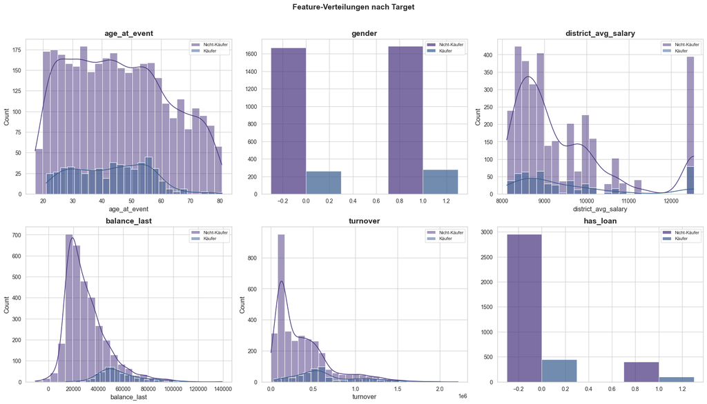

```python
# === Feature-Verteilungen nach Target (Baseline Features) ===

fig, axes = plt.subplots(2, 3, figsize=(18, 10))
plot_features = BASELINE_FEATURE_COLS + ["has_loan"]
colors = {0: "C0", 1: "C1"}
labels = {0: "Nicht-Käufer", 1: "Käufer"}

for idx, feat in enumerate(plot_features):
    ax = axes[idx // 3, idx % 3]
    for t in [0, 1]:
        subset = feature_matrix[feature_matrix["target"] == t]
        if subset[feat].nunique() <= 5:
            # Categorical/binary: bar chart
            counts = subset[feat].value_counts().sort_index()
            offset = -0.15 if t == 0 else 0.15
            ax.bar(
                counts.index + offset,
                counts.values,
                width=0.3,
                alpha=0.7,
                label=labels[t],
                color=colors[t],
            )
        else:
            sns.histplot(
                subset[feat],
                bins=25,
                alpha=0.5,
                label=labels[t],
                ax=ax,
                kde=True,
                color=colors[t],
            )
    ax.set_title(feat)
    ax.legend(fontsize=8)

plt.suptitle("Feature-Verteilungen nach Target", fontsize=14, fontweight="bold", y=1.02)
plt.tight_layout()
plt.show()
```

### 8.2 Interpretation: Feature-Verteilungen nach Target

Die Histogramme zeigen die Verteilung der Baseline-Features getrennt nach Käufern (Target=1) und Nicht-Käufern (Target=0):

- **age_at_event:** Nicht-Käufer zeigen eine relativ gleichmässige Altersverteilung über alle Altersgruppen. Käufer hingegen konzentrieren sich stärker im Bereich 25–55 Jahre, mit einem deutlichen Rückgang bei Senioren (65+). Jüngere und mittelalte Kunden scheinen empfänglicher für Kreditkarten zu sein.
- **gender:** Die Geschlechterverteilung ist in beiden Gruppen nahezu identisch. Geschlecht allein ist kein starker Prädiktor für Kreditkarten-Affinität.
- **district_avg_salary:** Beide Gruppen haben eine ähnliche Verteilung, wobei Käufer eine leichte Tendenz zu höheren Durchschnittsgehältern zeigen (mehr Masse im rechten Bereich >10’000 CZK). Der Effekt ist aber subtil.
- **balance_last:** Beide Gruppen sind rechtsschief verteilt. Käufer zeigen tendenziell etwas höhere Kontostände, aber die Verteilungen überlappen stark. Das Vermögen allein reicht nicht zur Unterscheidung.
- **turnover:** Stark rechtsschief in beiden Gruppen. Käufer haben tendenziell einen etwas höheren Umsatz, aber auch hier gibt es grosse Überlappung. Die langen rechten Ausläufer deuten auf einige Konten mit sehr hohem Transaktionsvolumen hin.
- **has_loan:** Käufer haben einen deutlich höheren Anteil an Kreditnehmern als Nicht-Käufer. Dies ist einer der stärksten univariaten Unterschiede. Kunden mit bestehendem Kredit sind eher bereit, auch eine Kreditkarte zu akzeptieren.

**Fazit:** Kein einzelnes Baseline-Feature trennt die Gruppen vollständig. Die Verteilungen überlappen erheblich. Die stärksten univariaten Signale kommen von `has_loan` und `age_at_event`. Für eine gute Klassifikation werden die Interaktionen zwischen Features und die tsfresh-Zeitreihenfeatures entscheidend sein.

## 9 Korrelationsmatrix der handgefertigten Features

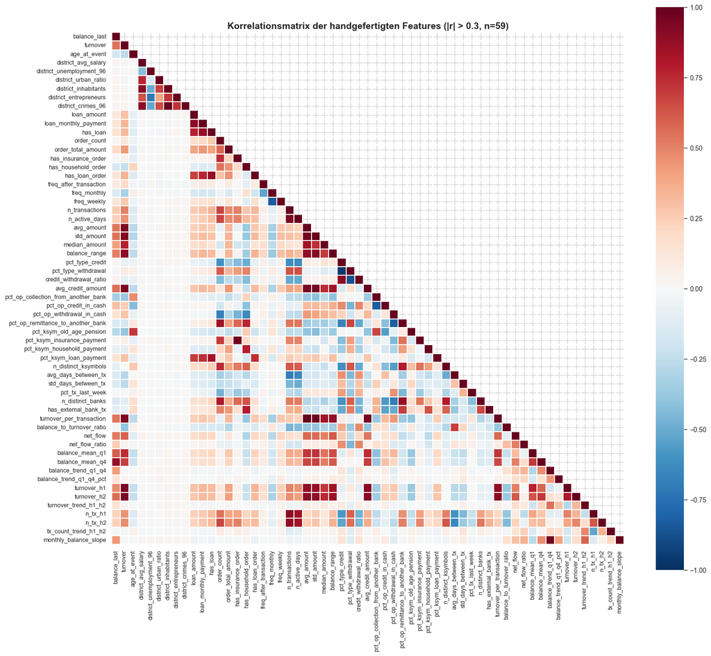

```python
# === Korrelationsmatrix der handgefertigten Features ===

hand_crafted_cols = [
    c
    for c in feature_matrix.columns
    if c not in ("account_id", "target", "split")
    and not c.startswith(TSFRESH_FEATURE_PREFIX)
]

corr_full = feature_matrix[hand_crafted_cols].corr()

# Nur Features behalten, die mit mindestens einem anderen Feature |r| > 0.3 haben
mask_diag = np.eye(len(corr_full), dtype=bool)
has_strong_corr = corr_full.abs().where(~mask_diag).max(axis=1) > 0.3
selected_cols = corr_full.columns[has_strong_corr].tolist()
corr = corr_full.loc[selected_cols, selected_cols]

fig, ax = plt.subplots(figsize=(16, 14))
mask = np.triu(np.ones_like(corr, dtype=bool), k=1)
sns.heatmap(
    corr,
    mask=mask,
    annot=False,
    cmap="RdBu_r",
    center=0,
    vmin=-1,
    vmax=1,
    ax=ax,
    square=True,
    linewidths=0.3,
    linecolor="white",
)
ax.set_title(
    f"Korrelationsmatrix der handgefertigten Features (|r| > 0.3, n={len(selected_cols)})"
)
ax.tick_params(axis="x", labelsize=9, rotation=90)
ax.tick_params(axis="y", labelsize=9, rotation=0)
plt.tight_layout()
plt.show()
```

### 9.1 Interpretation: Korrelationsmatrix

Die gefilterte Heatmap zeigt 59 von ~64 handgefertigten Features, die mit mindestens einem anderen Feature eine Korrelation von |r| > 0.3 aufweisen. Vier Korrelationsblöcke sind klar erkennbar:

**Kredit-Block:** `loan_amount`, `loan_monthly_payment` und `has_loan` sind erwartungsgemäss stark korreliert, da `loan_amount` und `loan_monthly_payment` nur für Konten mit aktivem Kredit von null verschieden sind.

**Betrags-Block:** `avg_amount`, `std_amount`, `median_amount`, `balance_range` und `turnover_per_transaction` bilden einen roten Cluster. Diese Features messen alle dasselbe Betragsniveau aus unterschiedlichen statistischen Blickwinkeln.

**Window-Block:** Die temporalen Sub-Fenster-Features (`balance_mean_q1`, `balance_mean_q4`, `turnover_h1`, `turnover_h2`, `n_tx_h1`, `n_tx_h2`, etc.) sind untereinander stark positiv korreliert. Konten mit hohem Umsatz in einem Halbjahr weisen typischerweise auch im anderen hohe Werte auf, was auf stabiles Transaktionsverhalten hinweist. Zusätzlich korrelieren `balance_last` und `turnover` mit den Window Features, da die Rollup-Gesamtwerte die Summe der Teilfenster widerspiegeln.

**Negative Korrelationen:** `pct_type_credit` und `pct_type_withdrawal` sind nahezu perfekt negativ korreliert, da sie sich definitionsgemäss zu ~1 ergänzen. Dasselbe gilt für `freq_monthly` und `freq_weekly` als One-Hot-kodierte Kategorien.

**Implikation für Modeling:** Die hohe Multikollinearität innerhalb der vier Blöcke ist für baumbasierte Modelle unproblematisch. Für die logistische Regression im Baseline-Modell empfiehlt sich je ein Vertreter pro Block, um Koeffizienteninstabilität zu vermeiden.

```python
# === tsfresh Feature Selection: Statistische Relevanz ===

# Nur tsfresh Features für die Selektion
tsf_cols = [c for c in feature_matrix.columns if c.startswith(TSFRESH_FEATURE_PREFIX)]
X_tsf = feature_matrix[tsf_cols].copy()
y = feature_matrix["target"].copy()

# Nur Train-Daten für die Feature-Selektion verwenden (kein Leakage)
train_mask = feature_matrix["split"] == "train"
X_tsf_train = X_tsf[train_mask].copy()
y_train = y[train_mask].copy()

# NaN-Werte auffüllen (2 Accounts ohne Transaktionen im Rollup haben NaN für alle tsfresh Features)
nan_rows = X_tsf_train.isna().any(axis=1).sum()
if nan_rows > 0:
    print(
        f"Hinweis: {nan_rows} Accounts mit NaN in tsfresh Features (keine Transaktionen im Rollup) — werden mit 0 aufgefüllt"
    )
    X_tsf_train = X_tsf_train.fillna(0)

print(f"tsfresh Features vor Selektion: {X_tsf_train.shape[1]}")
X_selected = select_features(X_tsf_train, y_train)
selected_cols = X_selected.columns.tolist()
print(f"tsfresh Features nach Selektion: {len(selected_cols)}")
print(
    f"Reduktion: {X_tsf_train.shape[1] - len(selected_cols)} Features entfernt ({(1 - len(selected_cols)/X_tsf_train.shape[1])*100:.1f}%)"
)
print(f"\nTop-20 selektierte Features:")
for col in selected_cols[:20]:
    print(f"  {col}")
```

```
Hinweis: 2 Accounts mit NaN in tsfresh Features (keine Transaktionen im Rollup) — werden mit 0 aufgefüllt
tsfresh Features vor Selektion: 1066
tsfresh Features nach Selektion: 476
Reduktion: 590 Features entfernt (55.3%)

Top-20 selektierte Features:
  tsf_balance__quantile__q_0.3
  tsf_balance__mean
  tsf_balance__c3__lag_3
  tsf_balance__quantile__q_0.1
  tsf_balance__abs_energy
  tsf_balance__benford_correlation
  tsf_balance__quantile__q_0.9
  tsf_balance__agg_linear_trend__attr_"intercept"__chunk_len_50__f_agg_"max"
  tsf_balance__agg_linear_trend__attr_"intercept"__chunk_len_10__f_agg_"mean"
  tsf_amount__quantile__q_0.2
  tsf_balance__max_langevin_fixed_point__m_3__r_30
  tsf_balance__minimum
  tsf_balance__agg_linear_trend__attr_"intercept"__chunk_len_10__f_agg_"max"
  tsf_amount__absolute_sum_of_changes
  tsf_balance__agg_linear_trend__attr_"intercept"__chunk_len_10__f_agg_"min"
  tsf_balance__change_quantiles__f_agg_"var"__isabs_True__qh_0.8__ql_0.0
  tsf_amount__change_quantiles__f_agg_"mean"__isabs_True__qh_1.0__ql_0.4
  tsf_balance__agg_linear_trend__attr_"intercept"__chunk_len_50__f_agg_"min"
  tsf_amount__abs_energy
  tsf_amount__change_quantiles__f_agg_"var"__isabs_False__qh_1.0__ql_0.0
```

### 9.2 Interpretation: tsfresh Feature Selection

Die statistische Relevanztestung via `select_features()` (Benjamini-Hochberg-Korrektur) reduziert die bereits deduplizierten tsfresh-Features um **55.3%** (von 1’066 auf 476). Die eliminierten 590 Features sind statistisch nicht signifikant mit dem Target assoziiert (korrigierter p-Wert über dem Schwellenwert). Hinweis: Diese Selektion ist eine **explorative** Relevanz-Analyse; die finale Feature-Matrix behält bewusst alle 1’066 tsfresh-Features, da die Tree-Modelle irrelevante Features selbst heruntergewichten.

**Implikation:** Der Kontostand (balance) ist informativer als der Transaktionsbetrag (amount) für die Vorhersage der Kreditkarten-Affinität. Das ist inhaltlich plausibel: Der Saldo reflektiert die finanzielle Stabilität und Kapazität eines Kunden besser als einzelne Transaktionsbeträge.

```python
# === Feature Matrix speichern ===
os.makedirs(str(PATH_PROCESSED), exist_ok=True)
feature_matrix.to_parquet(str(PATH_PROCESSED / "feature_matrix.parquet"), index=False)

print(f"Feature Matrix gespeichert: {feature_matrix.shape}")
print(f"  Pfad: {PATH_PROCESSED / 'feature_matrix.parquet'}")
print(f"  Accounts: {feature_matrix.shape[0]}")
print(f"  Features: {len(feature_cols)}")
print(f"  Target=1: {(feature_matrix['target'] == 1).sum()}")
print(f"  Target=0: {(feature_matrix['target'] == 0).sum()}")
```

```
Feature Matrix gespeichert: (3893, 1133)
  Pfad: /Users/lucamanna/Documents/00_Coding/fhnw/06_AngewandteDataScience/aml/aml/data/processed/feature_matrix.parquet
  Accounts: 3893
  Features: 1130
  Target=1: 540
  Target=0: 3353
```

## 10 Zusammenfassung

### 10.1 Feature-Kategorien

[output not shown]

### 10.2 Nächste Schritte (Phase 3: Modeling)

1. **Baseline-Modell:** Logistische Regression mit den 5 Baseline-Features
2. **Handcrafted-Modell:** Logistische Regression mit ~65 handgefertigten Features (ohne tsfresh)
3. **Kandidatenmodelle:** RandomForest, HistGBT und XGBoost mit allen ~1’130 Features
4. **Hyperparameter-Tuning:** RandomizedSearch mit stratifizierter k-Fold CV
5. **Evaluation:** ROC-AUC, Precision, Recall, Lift Curve